# Which group should ‘Prosper’ target to maximize profit?

```
                                                              by JINSOO KIM
```

# Introduction

What is ‘Prosper’?  
Prosper was founded in 2005 as the first peer-to-peer lending marketplace in the United States. Since then, Prosper has facilitated more than $12 billion in loans to more than 770,000 people. If you want more details, check this link(https://www.prosper.com/home/about).

The initial dataframe provides Prosper data that was made from Nov 2005 to Mar 2014. Analyzing this dataframe by univariate, bivariate, and multivariate plots, I would like to find some insights to maximize profit.

To maximize profit I would have basic assumptions.  
1. Marketing resources(time and money) are limited. 2. Buoyant market, groups are more prone to make additional profitable loans.

## 1. Data wrangling.

Before Analysis, I found Duplicated ‘ListingKey’ in dataset. The total number of row is as below.

```
## # A tibble: 1 x 1
##        n
##    <int>
## 1 113937
```

In the other hand, the number of unique ListingKey is somewhat different as below.

```
## # A tibble: 1 x 1
##        n
##    <int>
## 1 113066
```

Below are the examples of duplicated ListingKey.

```
## # A tibble: 5 x 2
##   ListingKey                  n
##   <fct>                   <int>
## 1 17A93590655669644DB4C06     6
## 2 349D3587495831350F0F648     4
## 3 47C1359638497431975670B     4
## 4 8474358854651984137201C     4
## 5 DE8535960513435199406CE     4
```

I found that for each ListingKey, only the ProsperScores are different.

I decide to delete all 827 duplicated ListingKeys because there are not enough information that which one is valuable.

From now Only unique ListingKeys are in the data frame.

## 2. Univariate Plots Section

2-1 Loan creation date distribution

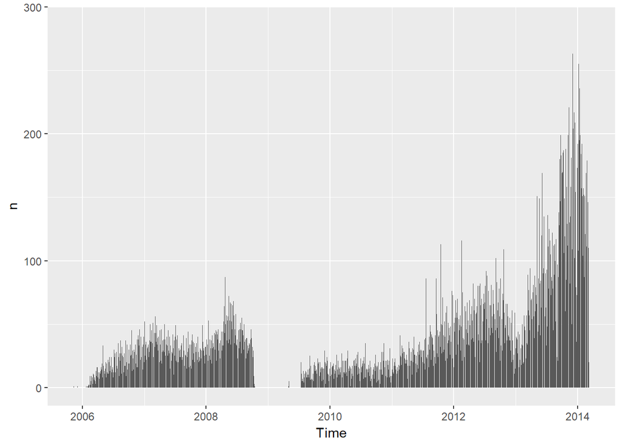

1. Variables (ProsperRating (Alpha) & ProsperScore) are only available from July 2009.
2. To predict, using recent data only is better than with a big pausing gap Plus, the shape and number of loans are quite different.

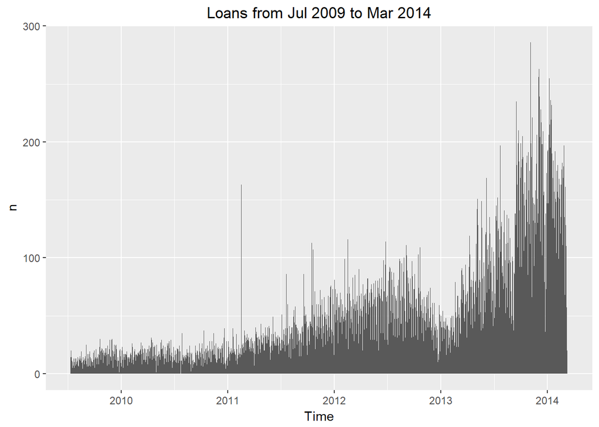

[output not shown]

2-2 Occupation distribution

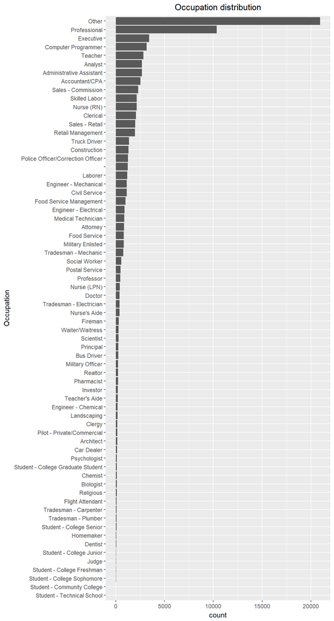

2-3 Reasons to borrow money distribution

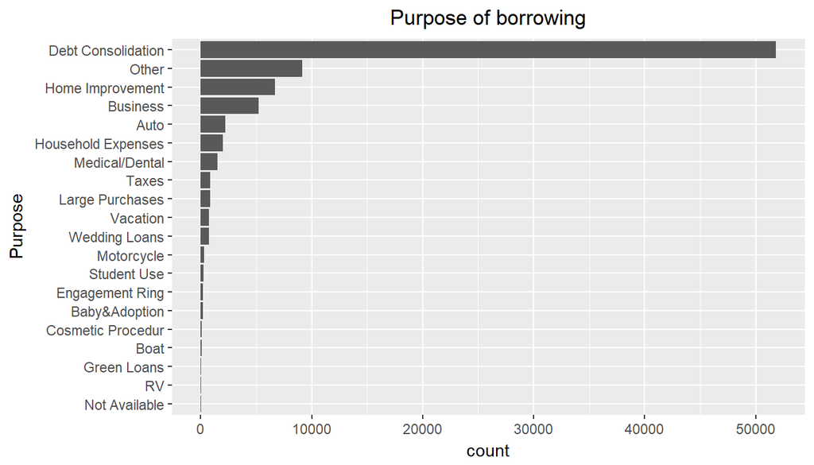

2-4 Loan distribtion by States

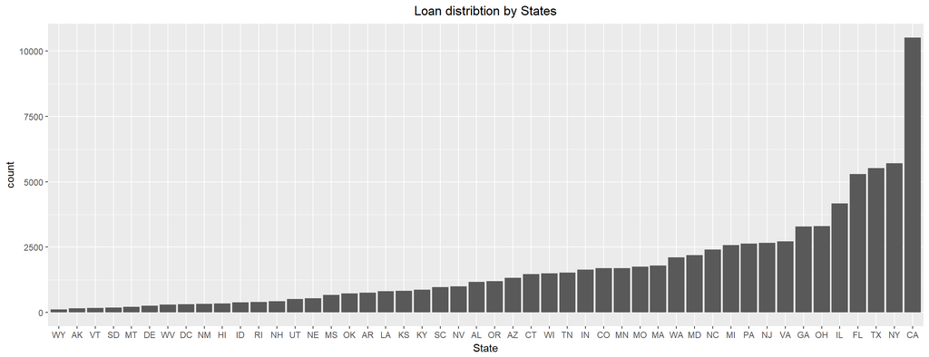

2-5 LenderYield distribution

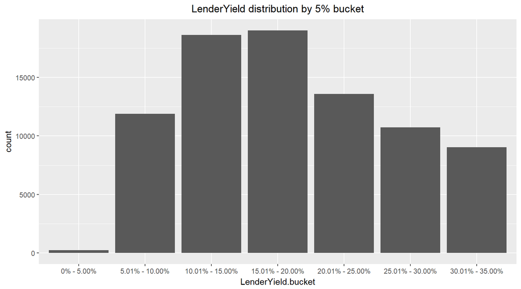

High LenderYield means high profit when the amount of each loan is equivalent.

```
##    Min. 1st Qu.  Median    Mean 3rd Qu.    Max.
##  0.0300  0.1259  0.1797  0.1866  0.2479  0.3400
```

For better profit, I suggest Prosper would more focus on loans that yield is higher than 0.1797(Median).

2-6 Loan Original Amount distribution

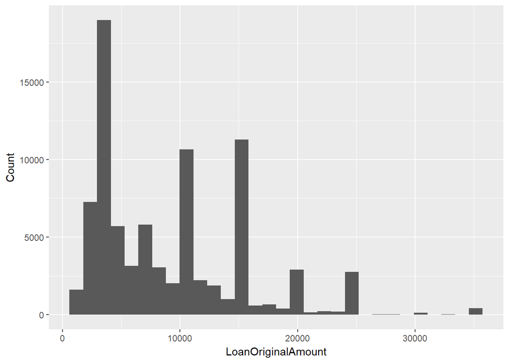

We can see that most of Loans are under USD 20,000. If the yield is equivalent for each loan, loans with high amount of money are more profitable.

2-7 Prosper score distribution

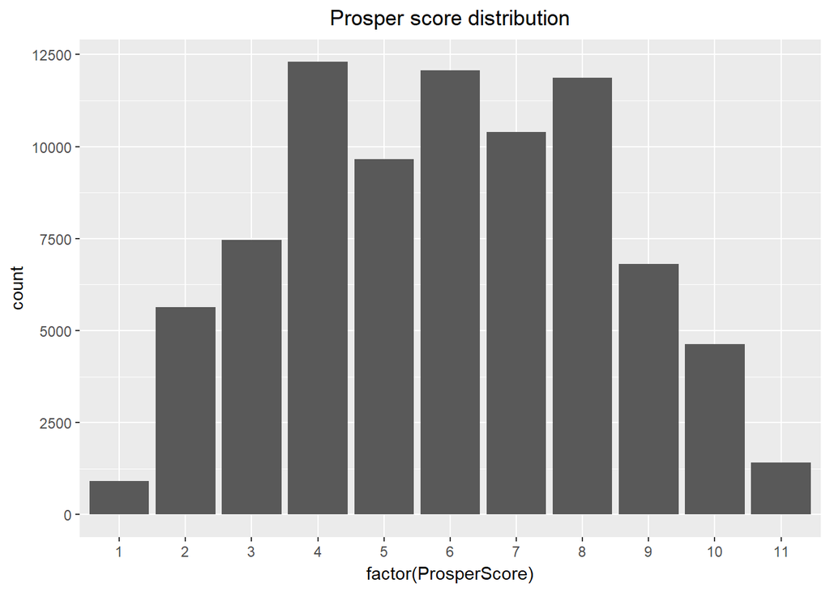

A custom risk score built using historical Prosper data. The higher score, the less risky.

2-8 Prosper Rating distribution

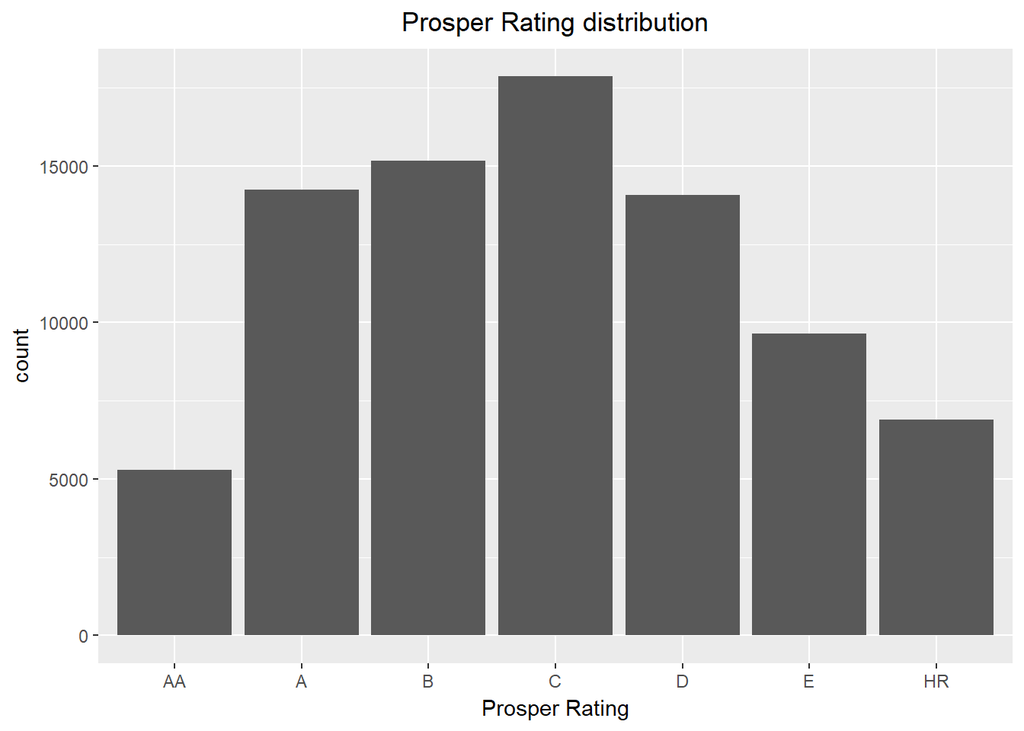

Rating “AA” means the lowset interest rate and “HR” means the highest with High Risk.

2-9 Income Range Distribution

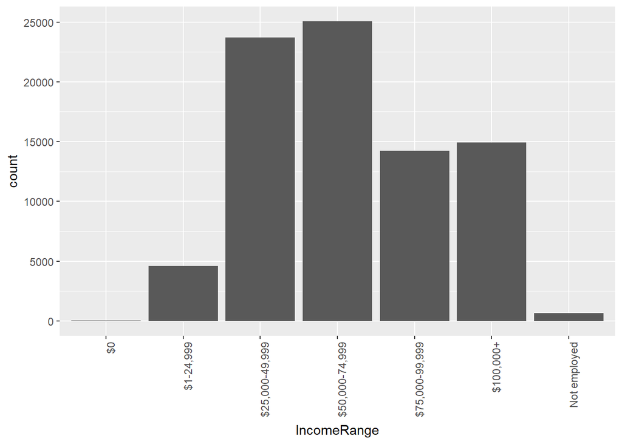

2-10 “RightTimePayments(Variable that I added)” Ratio distribution

> **1. OnTimeProsperPayments** , **2. ProsperPaymentsLessThanOneMonthLate**

By checking above variables, I would be able to predict people can pay back(On time or late but less than one month) or not.

Before investigating two variables, need to see the entire data. Many of them do not have prior loan records. Therefore, this is only valid analysis for the people who had the loan records.

This is the total number of the people who had the loan records before.

```
## [1] 19479
```

Now I would add a new variable “**RightTimePayments**” which means (“**OnTimeProsperPayments**” + “**ProsperPaymentsLessThanOneMonthLate**”) / “**TotalProsperPaymentsBilled**”.

The ratio of “RightTimePayments” will be considered as we can trust the people would pay the bill.

```
## [1] 0.9984599
```

It is 0.9984599, almost 100%. So I consider the people who had the loan records before will pay back properly.

## 2-11 Univariate Analysis

### 1) Structure of this dataset

> This dataset consists of 81 variables and 113,937 loans. Some of ListingKeys are duplicated.Therefore I removed them. 81 variables are quite a lot. Some variables are related, others are not. I chose 8 variables to make better profits.

### 2) Main features of this dataset?

> - Which kind of people borrow the most.  
>   Before starting, I had an assumiption. High borrow rate group has more chances to grow loans. Incomes range, Occupations, Borrowing reason, Region, Loan Creation date, Prosper Score & Rating are all to measure first feature.
> - Big benefit. If LenderYield is small, the amount of loans is not much. I thought LenderYield variable can measure the benefit.

## 3. Bivariate Plots Section

## 3-1 Relationship between ProsperScore and ProsperRating

If above both variables do not have linear relation, we need to set a new standard for risk score.

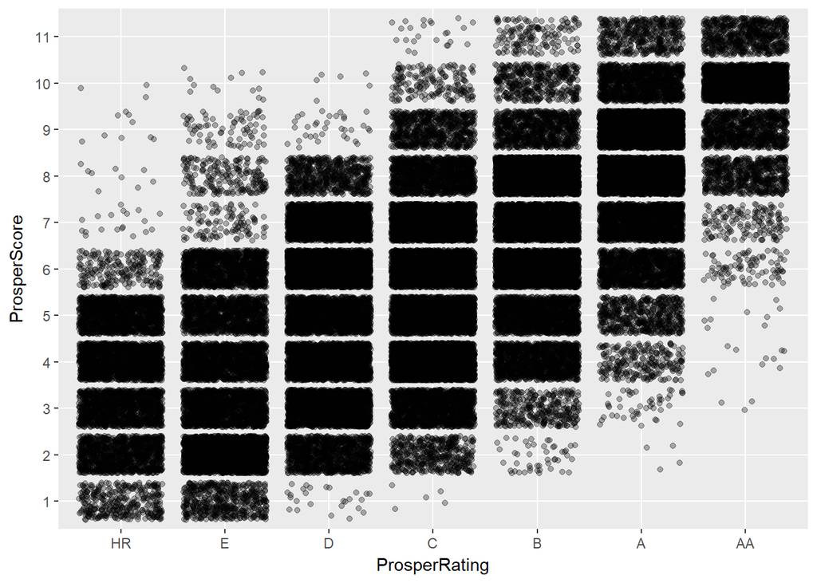

Bivariate plot seems linear.

In addition, correlation coefficient is 0.708 which means this is valid for strong relationship between two variables.

```
## [1] 0.7082547
```

## 3-2 Relationship between LenderYield and Loan original amount

The amount of loan and the LenderYield play a significant role in Prosper’s business.

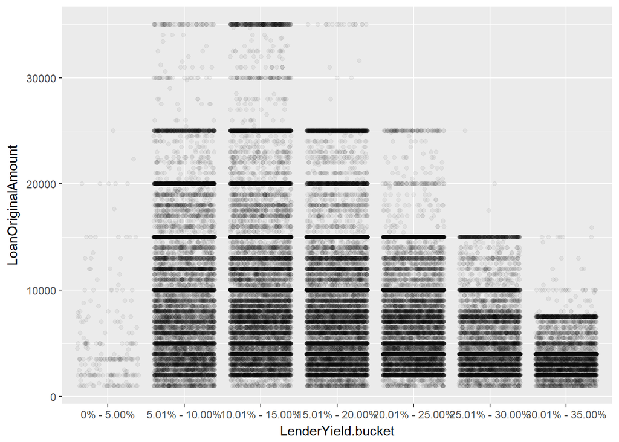

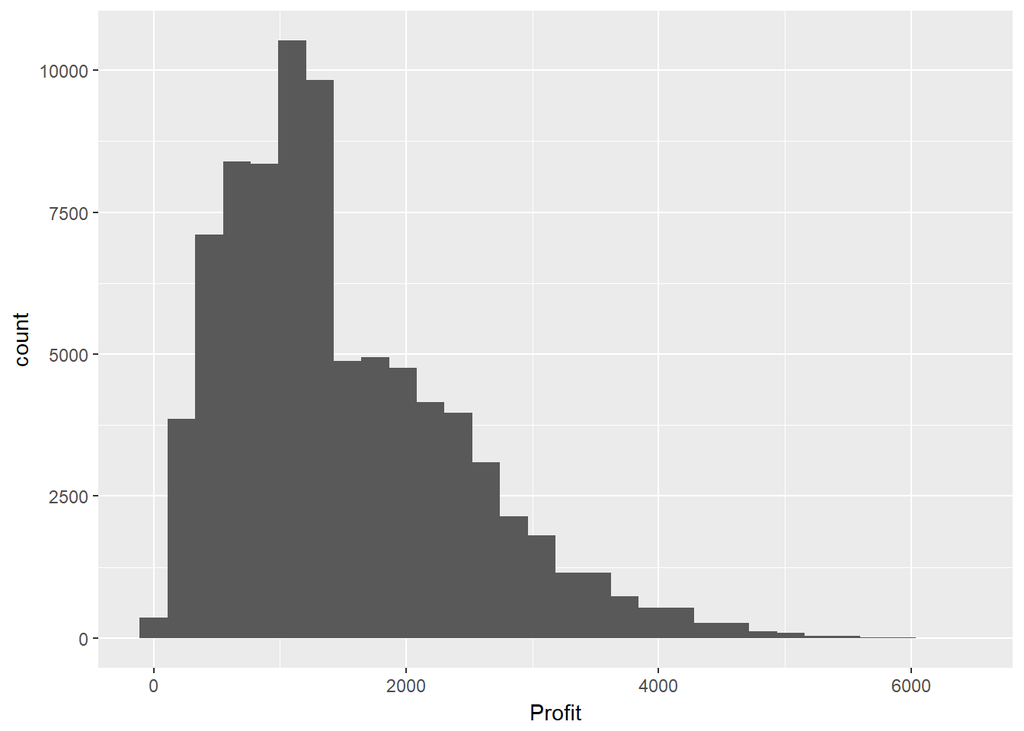

From now, I would use this variable ‘**Profit**’ as a measure how much money Prosper can earn. Below is summary of Profit.

```
##    Min. 1st Qu.  Median    Mean 3rd Qu.    Max.
##    30.0   792.5  1230.8  1492.2  2053.5  6395.0
```

If same inputs(time and money) are required to make one loan, the loans with big profit are good to make more money. So focusing on high profit (I assume here this is 1,230.8 which is Median value) would be an appropriate starategy.

## 3-3 Average profit distribution by Occupation

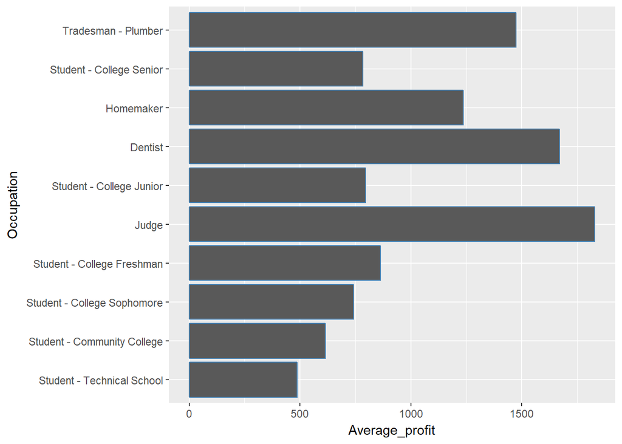

## 3-4 Average profit distribution by Borrowing reasons

There are 20 reasons, but I am only listing half to focus.

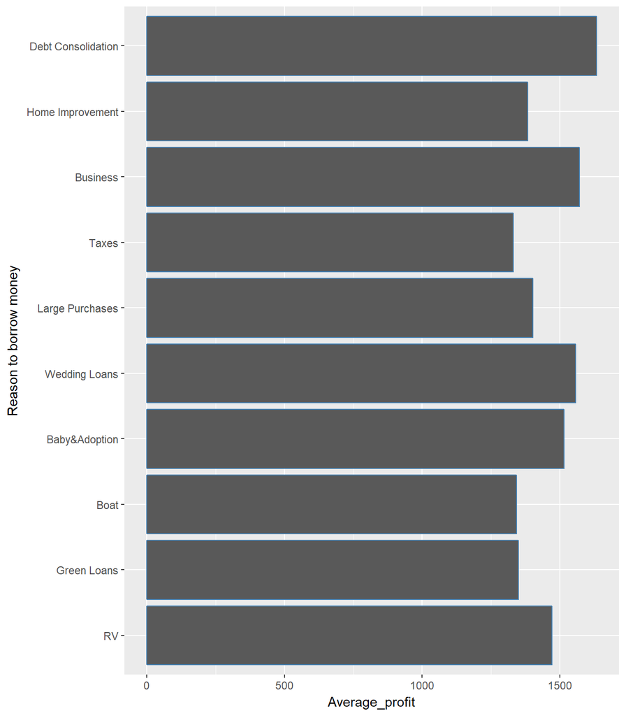

## 3-5 Average profit distribution by states

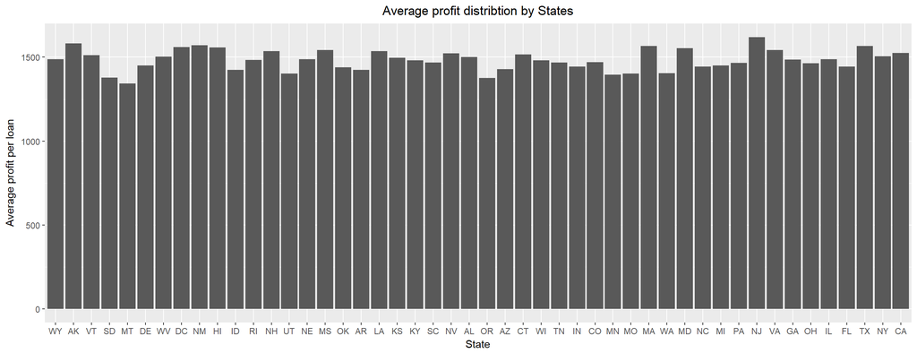

NJ(New Jersey) has the highest(1620.186) average profit per loan and MT(Montana) is the lowset(1344.100).

I consider the difference between two are not big. So, rather than profit, the states with many loans needs to be focused on.

Here are Top 10 borrow the most states.

```
## # A tibble: 10 x 2
##    BorrowerState     n
##    <fct>         <int>
##  1 CA            10524
##  2 NY             5709
##  3 TX             5523
##  4 FL             5302
##  5 IL             4168
##  6 OH             3308
##  7 GA             3284
##  8 VA             2725
##  9 NJ             2657
## 10 PA             2634
```

## 3-6 Average profit distribution by IncomeRange

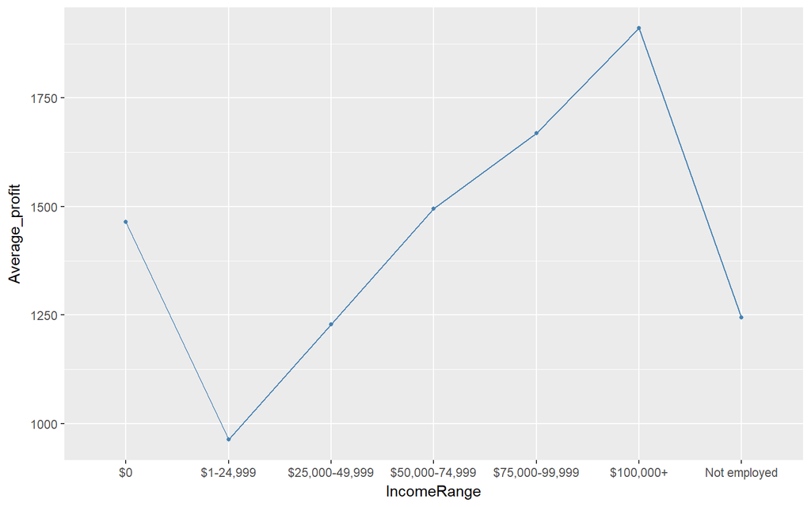

There is a big gap by each IncomeRange.  
Average Profit of **$ 100,000+** income range is as almost twice as it of **$ 1-24,999** income range.

## 3-7 Profit distribution by ProsperScore

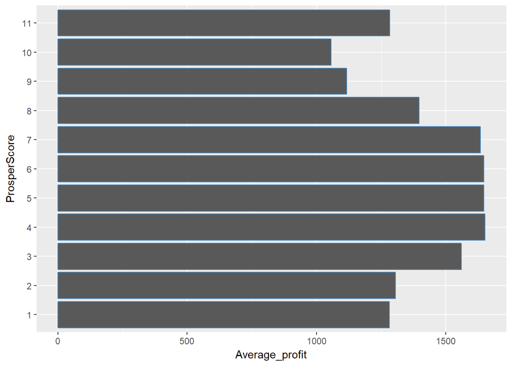

The difference between each ProsperScore’s Average_profit is not considered extreme. So it will be better to pick and focus the ProsperScores with many loans.

```
## # A tibble: 5 x 2
##   ProsperScore     n
##          <dbl> <int>
## 1         4.00 12300
## 2         6.00 12064
## 3         8.00 11875
## 4         7.00 10392
## 5         5.00  9661
```

## 3-8 Bivariate Analysis

# 4. Multivariate Plots Section

differentiate the profit in Top 5 states that have the most loans.

### 4-1 Profits by IncomeRange, Occupation on 5 states

```
## # A tibble: 6 x 2
##   Occupation               profits
##   <fct>                      <dbl>
## 1 Other               130095828621
## 2 Professional         85405287033
## 3 Executive            42950835246
## 4 Computer Programmer  26443813033
## 5 Nurse (RN)           22300085098
## 6 Analyst              22272997571
```

```
##  [1] $1-24,999      $25,000-49,999 $50,000-74,999 $75,000-99,999
##  [5] $100,000+      $1-24,999      $25,000-49,999 $50,000-74,999
##  [9] $75,000-99,999 $100,000+      $1-24,999      $25,000-49,999
## [13] $50,000-74,999 $75,000-99,999 $100,000+      $1-24,999
## [17] $25,000-49,999 $50,000-74,999 $75,000-99,999 $100,000+
## [21] $0             $1-24,999      $25,000-49,999 $50,000-74,999
## [25] $75,000-99,999 $100,000+
## 6 Levels: $0 $1-24,999 $25,000-49,999 $50,000-74,999 ... $100,000+
```

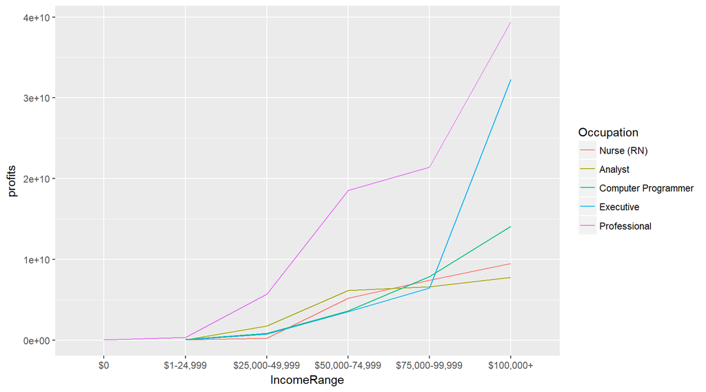